# Proyecto_de_clasificación_de_imágenes_médicas_con_modelo_pre-entrenado

Febrero, 2022

## Instalación de dependencias

Nota: si es la primera vez que ejecutas el notebook cambia la variable a TRUE (T) para instalar las dependencias. La primera ejecución tardará varios minutos en finalizar.

```r
install <- F
if (install==T){
install.packages("keras")
install.packages("httr")
install.packages("tidyverse")
install.packages("rmarkdown")
install.packages("reshape2")
install.packages("patchwork")

}
```

## Carga de dependencias

Lo primero que debemos hacer es cargar las dependencias (librerías) que vamos a necesitar en nuestro análisis. El paquete de R más representativo de este conjunto de dependencias es [Keras](https://keras.io/). En este post ya comentamos sobre el uso de Keras como framework de Deep Learning.

```r
library(tidyverse)
library(httr)
library(rmarkdown)
library(keras)
library(reshape2)
library(patchwork)
```

## Acceso a datos

*Esta sección solo es importante para aquellos usuarios que deseen ejecutar el código en Google Colab*

Para ejecutar este Notebook en [Google Colab](https://colab.research.google.com/) debemos de importar los datos al espacio local de trabajo de Colab. Los pasos son los siguientes:

1. Accedemos a la [siguiente dirección](https://drive.google.com/file/d/18YrsDFt4e2q1MHtwZl4_dlhGo9GZ7gZa/view?usp=sharing) en Google Drive y descargamos el directorio comprimido de los datos.
2. Descomprimimos el directorio en nuestro ordenador local.
3. Creamos unos directorios en Google Colab para guardar los datos de las imágenes.

```r
#Creamos directorios locales
system("mkdir data")
```

```
mkdir: data: File exists
```

```r
system("mkdir data/Pneumothorax")
```

```
mkdir: data/Pneumothorax: File exists
```

```r
system("mkdir data/No-Finding")
```

```
mkdir: data/No-Finding: File exists
```

4. Subimos manualmente los ficheros de imagen de acuerdo a la organización de cada carperta a Google Colab. Para ello, hacemos clic con botón derecho sobre cada una de los nuevos directorios en Colab y subimos las imágenes correspondientes.

Una vez subidos los ficheros debemos de ver algo tal que así en Google Colab.

5. Subimos el modelo pre-entrenado (*disseasemodel*) a su directorio correspondiente.

[figure not shown]

# Lectura de datos

Utilizando esta función leemos y preprocesamos todas las imágenes con las que vamos a querer trabajar. Esta función procede del [post original](https://rpubs.com/spalladino14/653239) escrita por [Spencer Palladino](https://www.linkedin.com/in/spencer-palladino/).

```r
process_pix <- function(lsf) {
  img <- lapply(lsf, image_load, color_mode = "grayscale") # grayscale the image
  arr <- lapply(img, image_to_array) # turns it into an array
  arr_resized <- lapply(arr, image_array_resize,
                        height = 100,
                        width = 100) # resize
  arr_normalized <- normalize(arr_resized, axis = 1) #normalize to make small numbers
  return(arr_normalized)
}
```

En este fragmento de código cargamos las imágenes desde de los directorios donde las hemos dejado previamente.

```r
lsf <- list.files("./data/Pneumothorax", full.names = TRUE)

lsf2 <- lsf[1:length(lsf)]
dissease <- process_pix(lsf2)
```

```
Loaded Tensorflow version 2.8.0
```

```r
dissease <- dissease[,,,1]
dissease_reshaped <- array_reshape(dissease, c(nrow(dissease), 100*100))

# Imágenes de personas SIN patologías
lsf3 <- list.files("./data/No-Finding", full.names = TRUE)

lsf4 <- lsf3[1:length(lsf3)]

ndissease <- process_pix(lsf4)
ndissease  <- ndissease[,,,1]
ndissease_reshaped <- array_reshape(ndissease, c(nrow(ndissease), 100*100))
```

Tenemos 1500 imágenes de rayos-x de personas con enfermedad y 1500 imágenes de personas sin enfermedad.

# Visualización previa de los datos/imágenes

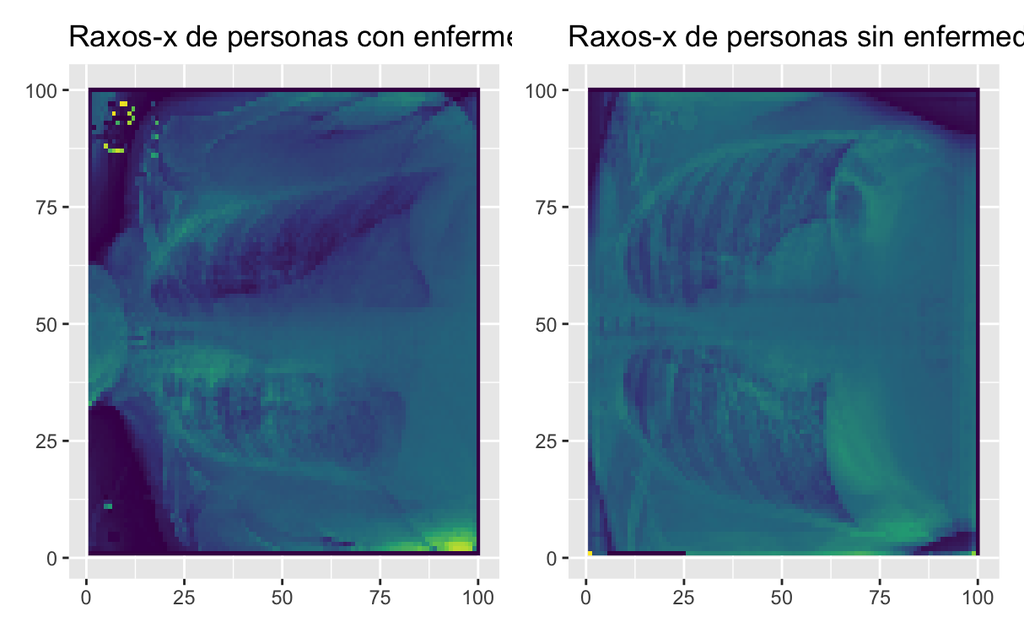

```r
scandissease <- reshape2::melt(dissease[10,,])
plotdissease <- scandissease %>%
  ggplot() +
  aes(x = Var1, y = Var2, fill = value) +
  geom_raster() +
  labs(x = NULL, y = NULL, title = "Raxos-x de personas con enfermedad") +
  scale_fill_viridis_c() +
  theme(legend.position = "none")

scanndissease <- reshape2::melt(ndissease[10,,])
plotndissease <- scanndissease %>%
  ggplot() +
  aes(x = Var1, y = Var2, fill = value) +
  geom_raster() +
  labs(x = NULL, y = NULL, title = "Raxos-x de personas sin enfermedad") +
  scale_fill_viridis_c() +
  theme(legend.position = "none")


plotdissease + plotndissease
```

# Comenzamos el análisis

Lo primero que vamos a hacer es mezclar las imágenes de pacientes con enfermedad y sin ella.

```r
df <- rbind(cbind(dissease_reshaped, 1), # 1 = dissease
            cbind(ndissease_reshaped, 0)) # 0 = no dissease
set.seed(1234)
shuffle <- sample(nrow(df), replace = F)
df <- df[shuffle, ]
```

# El modelo: Convolutional neural network (CNN)

Lo primero que hacemos dividir el conjunto total de imágenes en dos conjuntos siguiendo la proporción (80%/20%). Es decir, vamos a entrenar el algoritmo con el 80% de las imágenes y validarlo con el 20% restante.

```r
set.seed(2022)
split <- sample(2, nrow(df), replace = T, prob = c(0.8, 0.2))
train <- df[split == 1,]
test <- df[split == 2,]
train_target <- df[split == 1, 10001] # label in training dataset
test_target <- df[split == 2, 10001] # label in testing dataset
```

Convertimos las etiquetas de enfermedad/no-enfermedad a un tipo de datos de tipo factor o categórico.

```r
train_label <- to_categorical(train_target)
test_label <- to_categorical(test_target)
```

# El modelo pre-entrenado: Convolutional neural network (CNN)

Lo primero que hacemos es cargar un modelo pre-entrenado con 1500 imágenes de cada tipo. El entrenamiento de este modelo con esa cantidad tan grande imágenes requiere de una gran cantidad de espacio en disco para el almacenamiento de las imágenes además de alta potencia de cálculo en términos de CPU y memoria RAM. Por este motivo, para permitir al usuario ejecutar este notebook y comprobar los resultados del modelo debemos de partir de un modelo previamente entrenado. Si optaramos por reducir significativamente el número de imágenes de entrenamiento, la precisión del modelo decae rápidamente.

```r
#model <- load_model_tf("./model/disseasemodel/")

model <- load_model_hdf5("./model/disseasemodel/")
```

```r
fit_dissease <- model %>%
  fit(x = train,
      y = train_label,
      epochs = 25,
      batch_size = 512, # try also 256, 512
      verbose = 2,
      validation_split = 0.8)
```

```
1/1 - 1s - loss: 3.1407e-05 - accuracy: 1.0000 - val_loss: 3.0764e-06 - val_accuracy: 1.0000 - 647ms/epoch - 647ms/step
1/1 - 0s - loss: 5.5780e-05 - accuracy: 1.0000 - val_loss: 3.0442e-06 - val_accuracy: 1.0000 - 170ms/epoch - 170ms/step
1/1 - 0s - loss: 2.7636e-05 - accuracy: 1.0000 - val_loss: 3.0146e-06 - val_accuracy: 1.0000 - 172ms/epoch - 172ms/step
1/1 - 0s - loss: 2.3801e-05 - accuracy: 1.0000 - val_loss: 2.9882e-06 - val_accuracy: 1.0000 - 170ms/epoch - 170ms/step
1/1 - 0s - loss: 3.5510e-05 - accuracy: 1.0000 - val_loss: 2.9719e-06 - val_accuracy: 1.0000 - 181ms/epoch - 181ms/step
1/1 - 0s - loss: 3.2262e-05 - accuracy: 1.0000 - val_loss: 2.9599e-06 - val_accuracy: 1.0000 - 177ms/epoch - 177ms/step
1/1 - 0s - loss: 2.4954e-05 - accuracy: 1.0000 - val_loss: 2.9483e-06 - val_accuracy: 1.0000 - 169ms/epoch - 169ms/step
1/1 - 0s - loss: 4.1174e-05 - accuracy: 1.0000 - val_loss: 2.9490e-06 - val_accuracy: 1.0000 - 170ms/epoch - 170ms/step
1/1 - 0s - loss: 2.2634e-05 - accuracy: 1.0000 - val_loss: 2.9517e-06 - val_accuracy: 1.0000 - 172ms/epoch - 172ms/step
1/1 - 0s - loss: 2.8431e-05 - accuracy: 1.0000 - val_loss: 2.9507e-06 - val_accuracy: 1.0000 - 170ms/epoch - 170ms/step
1/1 - 0s - loss: 3.0215e-05 - accuracy: 1.0000 - val_loss: 2.9575e-06 - val_accuracy: 1.0000 - 173ms/epoch - 173ms/step
1/1 - 0s - loss: 2.6206e-05 - accuracy: 1.0000 - val_loss: 2.9589e-06 - val_accuracy: 1.0000 - 171ms/epoch - 171ms/step
1/1 - 0s - loss: 2.7966e-05 - accuracy: 1.0000 - val_loss: 2.9514e-06 - val_accuracy: 1.0000 - 163ms/epoch - 163ms/step
1/1 - 0s - loss: 3.2618e-05 - accuracy: 1.0000 - val_loss: 2.9347e-06 - val_accuracy: 1.0000 - 171ms/epoch - 171ms/step
1/1 - 0s - loss: 2.6555e-05 - accuracy: 1.0000 - val_loss: 2.9040e-06 - val_accuracy: 1.0000 - 172ms/epoch - 172ms/step
1/1 - 0s - loss: 1.5787e-05 - accuracy: 1.0000 - val_loss: 2.8717e-06 - val_accuracy: 1.0000 - 169ms/epoch - 169ms/step
1/1 - 0s - loss: 2.3465e-05 - accuracy: 1.0000 - val_loss: 2.8399e-06 - val_accuracy: 1.0000 - 178ms/epoch - 178ms/step
1/1 - 0s - loss: 2.1387e-05 - accuracy: 1.0000 - val_loss: 2.7997e-06 - val_accuracy: 1.0000 - 176ms/epoch - 176ms/step
1/1 - 0s - loss: 2.9341e-05 - accuracy: 1.0000 - val_loss: 2.7494e-06 - val_accuracy: 1.0000 - 169ms/epoch - 169ms/step
1/1 - 0s - loss: 2.4509e-05 - accuracy: 1.0000 - val_loss: 2.7086e-06 - val_accuracy: 1.0000 - 172ms/epoch - 172ms/step
1/1 - 0s - loss: 2.2202e-05 - accuracy: 1.0000 - val_loss: 2.6693e-06 - val_accuracy: 1.0000 - 176ms/epoch - 176ms/step
1/1 - 0s - loss: 1.8431e-05 - accuracy: 1.0000 - val_loss: 2.6281e-06 - val_accuracy: 1.0000 - 180ms/epoch - 180ms/step
1/1 - 0s - loss: 2.0500e-05 - accuracy: 1.0000 - val_loss: 2.5903e-06 - val_accuracy: 1.0000 - 174ms/epoch - 174ms/step
1/1 - 0s - loss: 2.0520e-05 - accuracy: 1.0000 - val_loss: 2.5549e-06 - val_accuracy: 1.0000 - 165ms/epoch - 165ms/step
1/1 - 0s - loss: 2.4338e-05 - accuracy: 1.0000 - val_loss: 2.5248e-06 - val_accuracy: 1.0000 - 169ms/epoch - 169ms/step
```

Una visualización rápida sobre como se comporta el algoritmo sobre las imágenes que hemos reservado para validar.

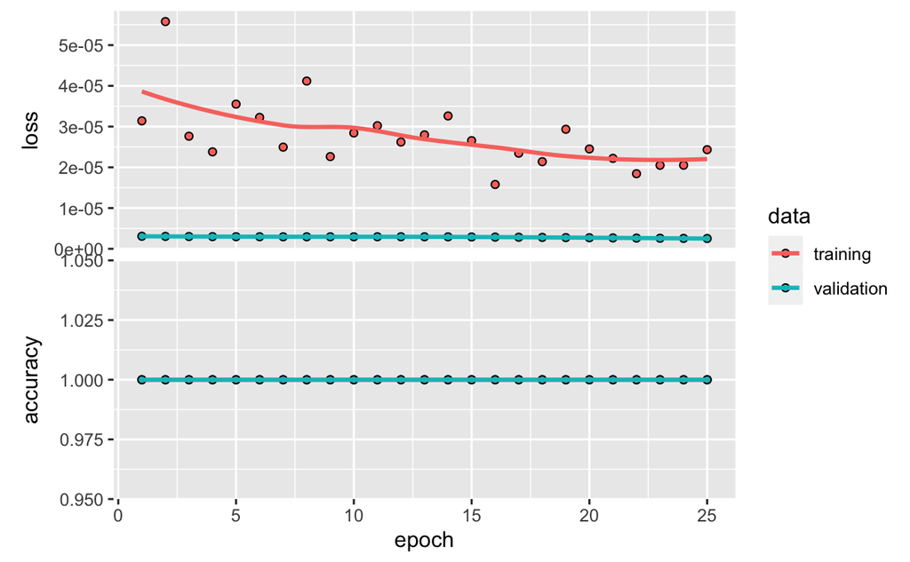

```r
plot(fit_dissease)
```

Calculamos las métricas de rendimiento del algoritmo.

```r
model %>%
  evaluate(test, test_label)
```

```
        loss     accuracy
2.775163e-06 1.000000e+00
```

```r
predictedclasses <- model %>%
  predict(test) %>% `>`(0.5) %>% k_cast("int32")
```

```
2022-06-06 20:51:46.300393: I tensorflow/core/grappler/optimizers/custom_graph_optimizer_registry.cc:113] Plugin optimizer for device_type GPU is enabled.
```

```r
table(Prediction = as.numeric(predictedclasses[,2]), Truth = test_target)
```

```
          Truth
Prediction   0   1
         0 299   0
         1   0 291
```

# Conclusiones

Hemos entrenado una algoritmo de tipo CNN Convolutional neural network-CNN para realizar clasificaciones binarias (enfermo vs no-enfermo) sobre un conjunto de imágenes de rayos-x de pecho tanto de pacientes sanos como de pacientes con varias patologías. Por sencillez, hemos escogido pacientes sanos y pacientes que presentan un Pneumothorax previamente identificado por un médico. El resultado del entrenamiento nos ofrece un algoritmo de clasificación robusto para el screening automático.